# Topics: Sampling Distributions and Central Limit Theorem

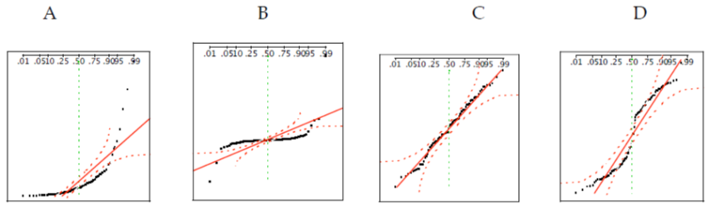

1.Examine the following normal Quantile plots carefully. Which of these plots indicates that the data … I. Are nearly normal? II. Have a bimodal distribution? (One way to recognize a bimodal shape is a “gap” in the spacing of adjacent data values.) III. Are skewed (i.e. not symmetric) ? IV. Have outliers on both sides of the center?

Answer:

I. C

II. D

III. A

IV. B

2.For each of the following statements, indicate whether it is True/False. If false, explain why.

The manager of a warehouse monitors the volume of shipments made by the delivery team. The automated tracking system tracks every package as it moves through the facility. A sample of 25 packages is selected and weighed every day. Based on current contracts with customers, the weights should have μ = 22 lbs. and σ = 5 lbs.

(i)Before using a normal model for the sampling distribution of the average package weights, the manager must confirm that weights of individual packages are normally distributed.

(ii)The standard error of the daily average SE(x ̅) = 1.

Answer:

(i) False .Because by using CLT we can bring a survey data to Normal distribution.So even though individual sample if not normally distributed too by CLT the resultant will be normally distributed.

(ii) True. Standard error is sample standard deviation / Square root of (number of sample) So SE=1

1. Auditors at a small community bank randomly sample 100 withdrawal transactions

made during the week at an ATM machine located near the bank’s main branch.

1. What is the

probability that in any given week, there will be an investigation?

A. 1.25%

B. 2.5%

C. 10.55%

D. 21.1%

E. 50%

```python
import numpy as np
import scipy.stats as stats
```

```python
 XAverage=50
 STD_SAMPLE=40
 n=100
 mu1=45
 mu2=55
 df=n-1
 alpha=0.05
```

```python
t_value1=(mu1 - XAverage)/((STD_SAMPLE)/np.sqrt(n))
t_value2=(mu2 - XAverage)/((STD_SAMPLE)/np.sqrt(n))
print("t_value1:", t_value1)
print("t_value2:", t_value2)
probability1=stats.norm.cdf(t_value1)
probability2=stats.norm.cdf(t_value2)
print("probability1:",probability1)
print("probability2:",probability2)
```

```
t_value1: -1.25
t_value2: 1.25
probability1: 0.10564977366685535
probability2: 0.8943502263331446
```

```python
p=probability2-probability1
print(p)
```

```
0.7887004526662893
```

```python
print("probability between 45:",p)
```

```
probability between 45: 0.7887004526662893
```

```python
if p<=alpha:
  print("Accept Alternate hypothesis,so There will be a chance of an investigation")
else:
  print("Reject Alternate hypothesis,so There will not be a chance of an investigation")
```

```
Reject Alternate hypothesis,so There will not be a chance of an investigation
```

1. The auditors from the above example would like to maintain the probability

of investigation to 5%. Which of the following represents the minimum number

transactions that they should sample if they do not want to change the

thresholds of 45 and 55? Assume that the sample statistics remain unchanged.

A. 144

B. 150

C. 196

D. 250

E. Not enough information

```python
t_value=stats.t.ppf((1-0.05/2),99)
t_value
n=(40*1.96)**2/25
print(n)
```

```
245.86240000000006
```

Answer

D.250

1. An educational startup that helps MBA aspirants write their essays is targeting

individuals who have taken GMAT in 2012 and have expressed interest in applying to

FT top 20 b-schools. There are **40000** such individuals with an average GMAT score of

720 and a standard deviation of 120. The scores are distributed between 650 and 790 with

a very long and thin tail towards the higher end resulting in substantial skewness.

Which of the following is likely to be true for randomly chosen samples of aspirants?

A. The standard deviation of the scores within any sample will be 120.

B. Thestandard deviation of the mean of across several samples will be 120.

C. The mean score in any sample will be 720.

D. The average of the mean across several samples will be 720.

E. The standard deviation of the mean across several samples will be 0.60

```python
X_avg=720
STD_samp=120
n=40000
#Standard_deviation_of_the_mean_across_several_samples is Standard_Error
Standard_Error=STD_samp/np.sqrt(n)
print(Standard_Error)
```

```
0.6
```

Answer

E.True